# Dissecting individual loci with eQTLs

Regina H. Reynolds

UCL

30 September 2021

> Aim: run univariate and bivariate analyses using eQTL data for select loci

# 1 Background

Bivariate local $r_{g}$ analyses revealed several loci (representing LD blocks) where significant $r_{g}$'s were found between multiple trait pairs. Of note, some LD blocks contained local $r_{g}$'s between neurodegenerative traits and between neuropscyhiatric traits, but with no overlap between the disorder groups. In addition, we observed LD blocks where several traits were associated with one trait in particular, but directions of effect were opposing (e.g. locus 1719, where BIP and MDD were positively correlated with SCZ, while LBD was negatively correlated with SCZ; or locus 2351, where AD and PD were positively and negatively correlated with LBD, respectively). Assuming that these assocations also correlate with expression quantitative trait loci (eQTLs), such differences may be driven by associations to different gene eQTLs.

# 2 Supplementary code

Following section includes any intermediary code used in this `.Rmd`.

## 2.1 Get gene loci

```r
source(here::here("scripts", "04a_get_gene_loci.R"))
```

All gene loci are shown below.

```r
gene_loci <-
  read_delim(
    file = here::here("results", "04_eqtl_univar_bivar", "gene_filtered.loci"),
    delim = "\t"
    )

gene_loci %>%
  DT::datatable(rownames = FALSE,
                options = list(scrollX = TRUE),
                class = 'white-space: nowrap')
```

| LOC | CHR | START | STOP |
| --- | --- | --- | --- |
| ENSG00000251095 | 4 | 90372507 | 90747654 |
| ENSG00000145335 | 4 | 90545250 | 90859466 |
| ENSG00000247775 | 4 | 90657559 | 90863129 |
| ENSG00000138722 | 4 | 90700683 | 90975780 |
| ENSG00000184305 | 4 | 90948686 | 92623064 |
| ENSG00000120885 | 8 | 27354434 | 27572548 |
| ENSG00000168077 | 8 | 27391385 | 27634293 |
| ENSG00000147419 | 8 | 27490835 | 27730170 |
| ENSG00000253875 | 8 | 27490855 | 27713943 |
| ENSG00000171320 | 8 | 27529466 | 27770157 |

[output cut: 82 more lines]

## 2.2 Pre-processing eQTL data

```r
source(here::here("scripts", "04b_preprocess_eqtl.R"))
```

## 2.3 Get sample overlap

```r
source(here::here("scripts", "04c_get_sample_overlaps.R"))
```

Subset of sample overlap matrix shown below.

```r
sample_overlap <-
  read.table(
    file = here::here("results", "04_eqtl_univar_bivar", "sample_overlap.txt")
    )

as.matrix(sample_overlap)[1:10,1:10]
```

```
##                          AD2019  BIP2021 LBD2020 MDD2019 PD2019.meta5.ex23andMe
## AD2019                  1.00000  0.00628 0.02589 0.01946                0.01193
## BIP2021                 0.00628  1.00000 0.00800 0.05997               -0.00150
## LBD2020                 0.02589  0.00800 1.00000 0.00040                0.01281
## MDD2019                 0.01946  0.05997 0.00040 1.00000                0.00436
## PD2019.meta5.ex23andMe  0.01193 -0.00150 0.01281 0.00436                1.00000
## SCZ2018                 0.01150  0.12928 0.00661 0.03615                0.00295
## EQTLGEN_ENSG00000007047 0.00000  0.00000 0.00000 0.00000                0.00000
## EQTLGEN_ENSG00000007255 0.00000  0.00000 0.00000 0.00000                0.00000
## EQTLGEN_ENSG00000041353 0.00000  0.00000 0.00000 0.00000                0.00000
## EQTLGEN_ENSG00000048028 0.00000  0.00000 0.00000 0.00000                0.00000
##                         SCZ2018 EQTLGEN_ENSG00000007047 EQTLGEN_ENSG00000007255
## AD2019                  0.01150                       0                       0
## BIP2021                 0.12928                       0                       0
## LBD2020                 0.00661                       0                       0
## MDD2019                 0.03615                       0                       0
## PD2019.meta5.ex23andMe  0.00295                       0                       0
## SCZ2018                 1.00000                       0                       0
## EQTLGEN_ENSG00000007047 0.00000                       1                       0
## EQTLGEN_ENSG00000007255 0.00000                       0                       1
## EQTLGEN_ENSG00000041353 0.00000                       0                       0
## EQTLGEN_ENSG00000048028 0.00000                       0                       0
##                         EQTLGEN_ENSG00000041353 EQTLGEN_ENSG00000048028
## AD2019                                        0                       0
## BIP2021                                       0                       0
## LBD2020                                       0                       0
## MDD2019                                       0                       0
## PD2019.meta5.ex23andMe                        0                       0
## SCZ2018                                       0                       0
## EQTLGEN_ENSG00000007047                       0                       0
## EQTLGEN_ENSG00000007255                       0                       0
## EQTLGEN_ENSG00000041353                       1                       0
## EQTLGEN_ENSG00000048028                       0                       1
```

## 2.4 Prepare input info file

```r
# Most input info already available, just need to add eqtls
input_info  <-
  read_delim(
    file = file.path(here::here("results", "01_input_prep"),
                     "input.info.txt"),
    delim = "\t"
  )

file_paths <-
  list.files(
      path = here::here("results", "04_eqtl_univar_bivar", "qtl_files"),
      pattern = "lava.gz",
      full.names = T
    )

input_info <-
  tibble(
    phenotype =
      basename(file_paths) %>%
      str_remove(".lava.gz"),
    cases = rep(1, times = length(file_paths)),
    controls = rep(0, times = length(file_paths)),
    filename = file_paths
  ) %>%
  dplyr::bind_rows(
    input_info
  )

write_delim(
  input_info,
  path = file.path(here::here("results", "04_eqtl_univar_bivar"),
                   "input.info.txt"),
  delim = "\t"
)
```

## 2.5 Run univariate and bivariate tests

This was run using `nohup`:

```bash
# Have to navigate to root project folder for script to work (as it uses here package)
cd /home/rreynolds/misc_projects/neurodegen-psych-local-corr

nohup Rscript \
/home/rreynolds/misc_projects/neurodegen-psych-local-corr/scripts/04d_run_univar_bivar_test.R \
&>/home/rreynolds/misc_projects/neurodegen-psych-local-corr/logs/04d_run_univar_bivar_test.log&
```

## 2.6 Loading results

Once run, results can be loaded using the following code chunk:

```r
results <-
  setNames(
    vector(mode = "list", length = 2),
    nm = c("univ", "bivar")
  )

for(i in 1:length(results)){

  results[[i]] <-
    setNames(
      object =
        list.files(
          path =
            here::here("results",
                       "04_eqtl_univar_bivar",
                       names(results)[i]),
          pattern = ".lava.rds",
          full.names = T
        ) %>%
        lapply(., function(file) readRDS(file)),
      nm =
        list.files(
          path =
            here::here("results",
                       "04_eqtl_univar_bivar",
                       names(results)[i]),
          pattern = ".lava.rds"
        ) %>%
        str_remove(., "\\..*.lava.rds")
    ) %>%
    purrr::discard(is.null) %>%
    qdapTools::list_df2df(col1 = "eqtl_gene") %>%
    dplyr::rename(
      gene_locus = locus
    ) %>%
    tidyr::separate(
      col = eqtl_gene,
      into = c("eqtl_dataset", NA),
      sep = ":"
    ) %>%
    dplyr::inner_join(
      gene_filtered_loci %>%
        dplyr::select(
          ld_block = locus, gene_id, gene_name
        ),
      by = c("gene_locus" = "gene_id")
    ) %>%
    dplyr::select(
      ld_block, eqtl_dataset, gene_locus, gene_name, everything()
    ) %>%
    dplyr::arrange(ld_block, gene_locus, eqtl_dataset)

}
```

## 2.7 Loading plotting functions

```r
source(here::here("R", "plots.R"))
```

# 3 Methods

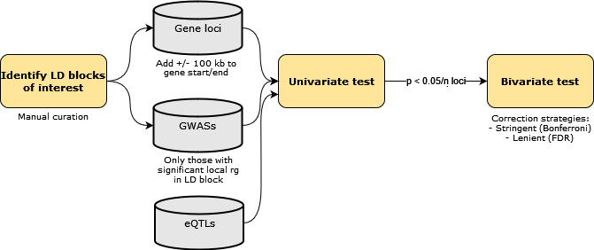

## 3.1 Deriving loci for eQTL analyses

Firstly, we determined a number of LD blocks of interest from the LD blocks highlighted by bivariate local $r_{g}$ analyses. LD blocks included:

- Two LD blocks where AD and PD were correlated, but the correlation was either positive or negative.
  - Locus 681, containing *SNCA*, which is of interest to PD
  - Locus 1273, containing *CLU*, which is of interest to AD
- An LD block where correlations were observed among neurodegenerative traits and among neuropsychiatric traits, but not between disorder groups, i.e. locus 2281, containing *RAB27B*
- Two LD blocks where several traits were associated with one trait in particular, but directions of effect were opposing.
  - Locus 1719, containing *DRD2*
  - Locus 2351, containing *APOE*

From these LD blocks of interest, we defined gene loci. That is, a 100 kb window was added to the start and end of any gene that overlapped a locus of interest. These gene-defined loci ($n$ = 92) were carried forward in downstream analyses.

## 3.2 Sample overlap

Due to the potential sample overlap between cohorts and its impact on any estimated correlations, it is advised to use cross-trait LDSC ([PMID:25642630](https://pubmed.ncbi.nlm.nih.gov/25642630/); [PMID:26414676](https://pubmed.ncbi.nlm.nih.gov/26414676/)) to obtain an estimate of the sample overlap. This, however, is not possible with eQTL summary statistics. Provided a reasonable certainty that there is no sample overlap between eQTL and GWAS summary statistics, it can be assumed to be zero (which precludes any correlations between eQTLGen and PsychENCODE, as both use GTEx samples, albeit from different tissues). **This, however, needs double-checking in terms of eQTL and GWAS cohorts.**

## 3.3 Running univariate and bivariate tests using eQTL summary statistics

For each gene locus, only those traits that were found to have significant local $r_{g}$ in the associated LD block were used for univariate and bivariate analyses with eQTL summary statistics. As described in 02_run_univar_bivar_test.html, a univariate test was performed as a filtering step for bivariate local $r_{g}$ analyses. Bivariate local correlations were only performed (i) if the eQTL within the gene locus exhibited a significant univariate local genetic signal and (ii) for pairs of traits which both exhibited a significant univariate local genetic signal. A cut-off of p < 0.0005434783 was used to determine univariate significance. This resulted in a total of **354** bivariate tests spanning **55** distinct gene loci. Bivariate results were multiple test corrected using two strategies: (i) a more stringent Bonferroni correction (i.e. p < 0.0001412429 and (ii) a more lenient FDR correction.

# 4 Results

## 4.1 Tabular results

### 4.1.1 Univariate results

```r
print("Univariate column descriptions:")
```

```
## [1] "Univariate column descriptions:"
```

```r
tibble(
  column = colnames(results$univ),
  description =
    c(
      "LD block",
      "eQTL dataset used",
      "Gene locus as identified by ensembl ID",
      "Gene name",
      "Gene locus chromosome",
      "Gene locus start base pair",
      "Gene locus end base pair",
      "The number of SNPs within the locus",
      "The number of PCs retained within the locus",
      "Analysed phenotype",
      "Observed local heritability",
      "P-value from the univariate test (F-test for continuous, Chi-sq for binary)"
    )
) %>%
  DT::datatable(rownames = FALSE,
                options = list(scrollX = TRUE),
                class = 'white-space: nowrap')
```

| column | description |
| --- | --- |
| ld_block | LD block |
| eqtl_dataset | eQTL dataset used |
| gene_locus | Gene locus as identified by ensembl ID |
| gene_name | Gene name |
| chr | Gene locus chromosome |
| start | Gene locus start base pair |
| stop | Gene locus end base pair |
| n_snps | The number of SNPs within the locus |
| n_pcs | The number of PCs retained within the locus |
| phen | Analysed phenotype |

[output cut: 2 more lines]

```r
print("Univariate results (p < 0.05/n_loci):")
```

```
## [1] "Univariate results (p < 0.05/n_loci):"
```

```r
results$univ <-
  results$univ %>%
  dplyr::mutate(
    phen =
      case_when(
        !str_detect(phen, "ENSG") ~ phen %>%
          str_replace_all("[:digit:]", "") %>%
          str_remove("\\..*"),
        str_detect(phen, "ENSG") ~ str_remove(phen, ".*_")
      )
  )

results$univ %>%
  dplyr::filter(p < 0.05/nrow(gene_loci)) %>%
  DT::datatable(rownames = FALSE,
                options = list(scrollX = TRUE),
                class = 'white-space: nowrap')
```

| ld_block | eqtl_dataset | gene_locus | gene_name | chr | start | stop | n_snps | n_pcs | phen | h2.obs | p |
| --- | --- | --- | --- | --- | --- | --- | --- | --- | --- | --- | --- |
| 681 | EQTLGEN | ENSG00000138722 | MMRN1 | 4 | 90700683 | 90975780 | 825 | 91 | AD | 0.00019525 | 5.19959e-07 |
| 681 | EQTLGEN | ENSG00000138722 | MMRN1 | 4 | 90700683 | 90975780 | 825 | 91 | PD | 0.00428725 | 0 |
| 681 | EQTLGEN | ENSG00000138722 | MMRN1 | 4 | 90700683 | 90975780 | 825 | 91 | ENSG00000138722 | 0.0451719 | 7.8491e-218 |
| 681 | PSYCHENCODE | ENSG00000138722 | MMRN1 | 4 | 90700683 | 90975780 | 527 | 47 | PD | 0.00165087 | 1.50773e-166 |
| 681 | PSYCHENCODE | ENSG00000138722 | MMRN1 | 4 | 90700683 | 90975780 | 527 | 47 | ENSG00000138722 | 0.0679426 | 1.38051e-11 |
| 681 | EQTLGEN | ENSG00000145335 | SNCA | 4 | 90545250 | 90859466 | 960 | 97 | AD | 0.000327289 | 2.26292e-13 |
| 681 | EQTLGEN | ENSG00000145335 | SNCA | 4 | 90545250 | 90859466 | 960 | 97 | PD | 0.00690998 | 0 |
| 681 | EQTLGEN | ENSG00000145335 | SNCA | 4 | 90545250 | 90859466 | 960 | 97 | ENSG00000145335 | 0.0919643 | 0 |
| 681 | PSYCHENCODE | ENSG00000145335 | SNCA | 4 | 90545250 | 90859466 | 600 | 52 | PD | 0.00228049 | 5.63918e-195 |
| 681 | EQTLGEN | ENSG00000184305 | CCSER1 | 4 | 90948686 | 92623064 | 4805 | 304 | AD | 0.00114863 | 6.41289e-41 |

[output cut: 381 more lines]

### 4.1.2 Bivariate results

- Multiple test correction is complicated by the many overlapping gene loci and the fact that we're repeatedly testing the same disease phenotypes within one LD block (and simply substituting the eQTL-gene)
- Thus, applied to multiple test correction strategies:
  - A stringent Bonferroni, correcting for all bivariate tests performed
  - A lenient FDR, correcting for all bivariate tests performed

```r
results$bivar <-
  results$bivar %>%
  dplyr::mutate(
    across(
      .cols = contains("phen"),
      ~ case_when(
        !str_detect(.x, "ENSG") ~ .x %>%
          str_replace_all("[:digit:]", "") %>%
          str_remove("\\..*"),
        str_detect(.x, "ENSG") ~ str_remove(.x, ".*_")
      )
    )
  ) %>%
  dplyr::ungroup() %>%
  dplyr::mutate(
    fdr = p.adjust(p, method = "fdr"),
    bonferroni = p.adjust(p, method = "bonferroni")
  )

print("Bivariate column descriptions:")
```

```
## [1] "Bivariate column descriptions:"
```

```r
tibble(
  column = colnames(results$bivar),
  description =
    c(
      "LD block",
      "eQTL dataset used",
      "Gene locus as identified by ensembl ID",
      "Gene name",
      "Gene locus chromosome",
      "Gene locus start base pair",
      "Gene locus end base pair",
      "The number of SNPs within the locus",
      "The number of PCs retained within the locus",
      "Phenotype 1",
      "Phenotype 2",
      "Standardised coefficient for the local genetic correlation",
      "Lower 95% confidence estimate for rho",
      "Upper 95% confidence estimate for rho",
      "Equivalent of taking the square of rho. Denotes the proportion of variance in genetic signal for phen1 explained by phen2 (and vice versa)",
      "Lower 95% confidence estimate for r2",
      "Upper 95% confidence estimate for r2",
      "Simulation p-values for the local genetic correlation",
      "FDR-corrected p-values",
      "Bonferroni-corrected p-values"
    )
) %>%
  DT::datatable(rownames = FALSE,
                options = list(scrollX = TRUE),
                class = 'white-space: wrap')
```

| column | description |
| --- | --- |
| ld_block | LD block |
| eqtl_dataset | eQTL dataset used |
| gene_locus | Gene locus as identified by ensembl ID |
| gene_name | Gene name |
| chr | Gene locus chromosome |
| start | Gene locus start base pair |
| stop | Gene locus end base pair |
| n_snps | The number of SNPs within the locus |
| n_pcs | The number of PCs retained within the locus |
| phen1 | Phenotype 1 |

[output cut: 10 more lines]

```r
print("Bivariate results (fdr < 0.05):")
```

```
## [1] "Bivariate results (fdr < 0.05):"
```

```r
bivar_fdr <-
  results$bivar %>%
  dplyr::filter(fdr < 0.05)

bivar_fdr %>%
  DT::datatable(rownames = FALSE,
                options = list(scrollX = TRUE),
                class = 'white-space: nowrap')
```

| ld_block | eqtl_dataset | gene_locus | gene_name | chr | start | stop | n_snps | n_pcs | phen1 | phen2 | rho | rho.lower | rho.upper | r2 | r2.lower | r2.upper | p | fdr | bonferroni |
| --- | --- | --- | --- | --- | --- | --- | --- | --- | --- | --- | --- | --- | --- | --- | --- | --- | --- | --- | --- |
| 681 | EQTLGEN | ENSG00000145335 | SNCA | 4 | 90545250 | 90859466 | 960 | 97 | AD | PD | -0.543489 | -0.70684 | -0.38758 | 0.29538 | 0.15022 | 0.49963 | 5.12598e-10 | 6.72072933333333e-09 | 1.81459692e-07 |
| 681 | EQTLGEN | ENSG00000145335 | SNCA | 4 | 90545250 | 90859466 | 960 | 97 | PD | ENSG00000145335 | -0.123173 | -0.17604 | -0.07155 | 0.0151717 | 0.00512 | 0.03099 | 4.39394e-06 | 2.93482030188679e-05 | 0.00155545476 |
| 1273 | EQTLGEN | ENSG00000120885 | CLU | 8 | 27354434 | 27572548 | 613 | 115 | AD | ENSG00000120885 | 0.173419 | 0.0598 | 0.28512 | 0.030074 | 0.00358 | 0.08129 | 0.00285952 | 0.00911955027027027 | 1 |
| 1273 | EQTLGEN | ENSG00000120885 | CLU | 8 | 27354434 | 27572548 | 613 | 115 | PD | ENSG00000120885 | -0.204806 | -0.31054 | -0.09811 | 0.0419455 | 0.00963 | 0.09643 | 0.000167211 | 0.00078923592 | 0.059192694 |
| 1273 | EQTLGEN | ENSG00000134014 | ELP3 | 8 | 27847190 | 28148673 | 745 | 164 | AD | PD | 0.152486 | 0.07408 | 0.22993 | 0.0232521 | 0.00549 | 0.05287 | 0.00015103 | 0.000722494864864865 | 0.05346462 |
| 1273 | EQTLGEN | ENSG00000134014 | ELP3 | 8 | 27847190 | 28148673 | 745 | 164 | PD | ENSG00000134014 | 0.0876699 | 0.03392 | 0.14151 | 0.00768601 | 0.00115 | 0.02003 | 0.0016347 | 0.005786838 | 0.5786838 |
| 1273 | PSYCHENCODE | ENSG00000134014 | ELP3 | 8 | 27847190 | 28148673 | 365 | 87 | AD | PD | 0.264787 | 0.06145 | 0.47224 | 0.070112 | 0.00417 | 0.22301 | 0.0111327 | 0.0307888734375 | 1 |
| 1273 | PSYCHENCODE | ENSG00000168077 | SCARA3 | 8 | 27391385 | 27634293 | 390 | 71 | AD | PD | 0.530217 | 0.41985 | 0.63562 | 0.28113 | 0.17628 | 0.40402 | 7.55048e-17 | 1.6705437e-15 | 2.67286992e-14 |
| 1273 | EQTLGEN | ENSG00000168078 | PBK | 8 | 27567137 | 27795612 | 865 | 92 | AD | PD | 0.141433 | 0.02628 | 0.25837 | 0.0200032 | 0.00082 | 0.06676 | 0.0187822 | 0.049618647761194 | 1 |
| 1273 | EQTLGEN | ENSG00000168078 | PBK | 8 | 27567137 | 27795612 | 865 | 92 | AD | ENSG00000168078 | 0.217687 | 0.08065 | 0.35091 | 0.0473877 | 0.0065 | 0.12314 | 0.00217861 | 0.007345028 | 0.77122794 |

[output cut: 124 more lines]

```r
print("Bivariate results (Bonferroni p < 0.05):")
```

```
## [1] "Bivariate results (Bonferroni p < 0.05):"
```

```r
bivar_bonf <-
  results$bivar %>%
  dplyr::filter(bonferroni < 0.05)

bivar_bonf %>%
  DT::datatable(rownames = FALSE,
                options = list(scrollX = TRUE),
                class = 'white-space: nowrap')
```

| ld_block | eqtl_dataset | gene_locus | gene_name | chr | start | stop | n_snps | n_pcs | phen1 | phen2 | rho | rho.lower | rho.upper | r2 | r2.lower | r2.upper | p | fdr | bonferroni |
| --- | --- | --- | --- | --- | --- | --- | --- | --- | --- | --- | --- | --- | --- | --- | --- | --- | --- | --- | --- |
| 681 | EQTLGEN | ENSG00000145335 | SNCA | 4 | 90545250 | 90859466 | 960 | 97 | AD | PD | -0.543489 | -0.70684 | -0.38758 | 0.29538 | 0.15022 | 0.49963 | 5.12598e-10 | 6.72072933333333e-09 | 1.81459692e-07 |
| 681 | EQTLGEN | ENSG00000145335 | SNCA | 4 | 90545250 | 90859466 | 960 | 97 | PD | ENSG00000145335 | -0.123173 | -0.17604 | -0.07155 | 0.0151717 | 0.00512 | 0.03099 | 4.39394e-06 | 2.93482030188679e-05 | 0.00155545476 |
| 1273 | PSYCHENCODE | ENSG00000168077 | SCARA3 | 8 | 27391385 | 27634293 | 390 | 71 | AD | PD | 0.530217 | 0.41985 | 0.63562 | 0.28113 | 0.17628 | 0.40402 | 7.55048e-17 | 1.6705437e-15 | 2.67286992e-14 |
| 1273 | EQTLGEN | ENSG00000168078 | PBK | 8 | 27567137 | 27795612 | 865 | 92 | PD | ENSG00000168078 | 0.338834 | 0.24382 | 0.4324 | 0.114809 | 0.05945 | 0.18697 | 1.6257e-11 | 2.877489e-10 | 5.754978e-09 |
| 1273 | EQTLGEN | ENSG00000168079 | SCARA5 | 8 | 27627399 | 27950244 | 1093 | 173 | AD | PD | 0.156312 | 0.07621 | 0.23329 | 0.0244334 | 0.00581 | 0.05442 | 0.000135027 | 0.00066388275 | 0.047799558 |
| 1273 | EQTLGEN | ENSG00000168081 | PNOC | 8 | 28074503 | 28300872 | 511 | 125 | PD | ENSG00000168081 | 0.204848 | 0.11483 | 0.29351 | 0.0419626 | 0.01319 | 0.08615 | 8.65326e-06 | 5.37412989473684e-05 | 0.00306325404 |
| 1273 | EQTLGEN | ENSG00000171320 | ESCO2 | 8 | 27529466 | 27770157 | 866 | 89 | PD | ENSG00000171320 | 0.455145 | 0.32587 | 0.58192 | 0.207157 | 0.10619 | 0.33863 | 1.0281e-10 | 1.5164475e-09 | 3.639474e-08 |
| 1273 | EQTLGEN | ENSG00000186918 | ZNF395 | 8 | 28103102 | 28360218 | 555 | 154 | AD | PD | 0.196635 | 0.12692 | 0.2655 | 0.0386652 | 0.01611 | 0.07049 | 7.01212e-08 | 7.09225851428571e-07 | 2.48229048e-05 |
| 1273 | EQTLGEN | ENSG00000189233 | NUGGC | 8 | 27779481 | 28041388 | 647 | 152 | AD | PD | 0.21155 | 0.12944 | 0.29369 | 0.0447535 | 0.01675 | 0.08625 | 5.92717e-07 | 5.11760531707317e-06 | 0.000209821818 |
| 1719 | EQTLGEN | ENSG00000149292 | TTC12 | 11 | 113085251 | 113354266 | 493 | 121 | MDD | SCZ | 0.686146 | 0.38032 | 1 | 0.470796 | 0.14464 | 1 | 8.84516e-05 | 0.000475444527272727 | 0.0313118664 |

[output cut: 62 more lines]

```r
print("Bivariate results (FDR < 0.05):")
```

```
## [1] "Bivariate results (FDR < 0.05):"
```

```r
bivar_fdr <-
  results$bivar %>%
  dplyr::filter(fdr < 0.05)

bivar_fdr %>%
  DT::datatable(rownames = FALSE,
                options = list(scrollX = TRUE),
                class = 'white-space: nowrap')
```

| ld_block | eqtl_dataset | gene_locus | gene_name | chr | start | stop | n_snps | n_pcs | phen1 | phen2 | rho | rho.lower | rho.upper | r2 | r2.lower | r2.upper | p | fdr | bonferroni |
| --- | --- | --- | --- | --- | --- | --- | --- | --- | --- | --- | --- | --- | --- | --- | --- | --- | --- | --- | --- |
| 681 | EQTLGEN | ENSG00000145335 | SNCA | 4 | 90545250 | 90859466 | 960 | 97 | AD | PD | -0.543489 | -0.70684 | -0.38758 | 0.29538 | 0.15022 | 0.49963 | 5.12598e-10 | 6.72072933333333e-09 | 1.81459692e-07 |
| 681 | EQTLGEN | ENSG00000145335 | SNCA | 4 | 90545250 | 90859466 | 960 | 97 | PD | ENSG00000145335 | -0.123173 | -0.17604 | -0.07155 | 0.0151717 | 0.00512 | 0.03099 | 4.39394e-06 | 2.93482030188679e-05 | 0.00155545476 |
| 1273 | EQTLGEN | ENSG00000120885 | CLU | 8 | 27354434 | 27572548 | 613 | 115 | AD | ENSG00000120885 | 0.173419 | 0.0598 | 0.28512 | 0.030074 | 0.00358 | 0.08129 | 0.00285952 | 0.00911955027027027 | 1 |
| 1273 | EQTLGEN | ENSG00000120885 | CLU | 8 | 27354434 | 27572548 | 613 | 115 | PD | ENSG00000120885 | -0.204806 | -0.31054 | -0.09811 | 0.0419455 | 0.00963 | 0.09643 | 0.000167211 | 0.00078923592 | 0.059192694 |
| 1273 | EQTLGEN | ENSG00000134014 | ELP3 | 8 | 27847190 | 28148673 | 745 | 164 | AD | PD | 0.152486 | 0.07408 | 0.22993 | 0.0232521 | 0.00549 | 0.05287 | 0.00015103 | 0.000722494864864865 | 0.05346462 |
| 1273 | EQTLGEN | ENSG00000134014 | ELP3 | 8 | 27847190 | 28148673 | 745 | 164 | PD | ENSG00000134014 | 0.0876699 | 0.03392 | 0.14151 | 0.00768601 | 0.00115 | 0.02003 | 0.0016347 | 0.005786838 | 0.5786838 |
| 1273 | PSYCHENCODE | ENSG00000134014 | ELP3 | 8 | 27847190 | 28148673 | 365 | 87 | AD | PD | 0.264787 | 0.06145 | 0.47224 | 0.070112 | 0.00417 | 0.22301 | 0.0111327 | 0.0307888734375 | 1 |
| 1273 | PSYCHENCODE | ENSG00000168077 | SCARA3 | 8 | 27391385 | 27634293 | 390 | 71 | AD | PD | 0.530217 | 0.41985 | 0.63562 | 0.28113 | 0.17628 | 0.40402 | 7.55048e-17 | 1.6705437e-15 | 2.67286992e-14 |
| 1273 | EQTLGEN | ENSG00000168078 | PBK | 8 | 27567137 | 27795612 | 865 | 92 | AD | PD | 0.141433 | 0.02628 | 0.25837 | 0.0200032 | 0.00082 | 0.06676 | 0.0187822 | 0.049618647761194 | 1 |
| 1273 | EQTLGEN | ENSG00000168078 | PBK | 8 | 27567137 | 27795612 | 865 | 92 | AD | ENSG00000168078 | 0.217687 | 0.08065 | 0.35091 | 0.0473877 | 0.0065 | 0.12314 | 0.00217861 | 0.007345028 | 0.77122794 |

[output cut: 124 more lines]

## 4.2 Significant bivariate local $r_{g}$'s at a global level

### 4.2.1 Text

- Using the more stringent Bonferroni cut-off, we detect a total of 72 significant bivariate local $r_{g}$'s across 41 distinct gene loci. When pairs of disease phenotypes (which were tested across multiple genes within an LD block) are collapsed within an LD block, we detect a total of 25 significant bivariate local $r_{g}$'s.
- By comparison, when the more lenient FDR cut-off, we detect a total of 134 significant bivariate local $r_{g}$'s across 47 distinct gene loci. When pairs of disease phenotypes (which were tested across multiple genes within an LD block) are collapsed within an LD block, we detect a total of 50 significant bivariate local $r_{g}$'s.
- Of the two eQTL datasets, the dataset with the highest number of gene loci (i.e. a gene where eQTLs were detected) was PsychENCODE (eQTLGen, n gene loci = 47; PsychENCODE, n gene loci = 87). In spite of this, the eQTL dataset with highest number of significant bivariate local $r_{g}$'s was eQTLGen, irrespective of the stringency of multiple test correction (Figure 4.1, 4.2). This likely reflects the bias in the selection of the LD blocks, which were weighted towards the AD/PD phenotypes, where we might expect to see a greater association with blood-derived molecular phenotypes.
- Given that gene loci might vary in size, we plotted the number of SNPs within a locus and the p-value from the univariate test to determine whether there was a relationship between locus size and univariate p-value. There was no apparent relationship between the two (as determined by visual inspection, Figure 4.3).

### 4.2.2 Figures

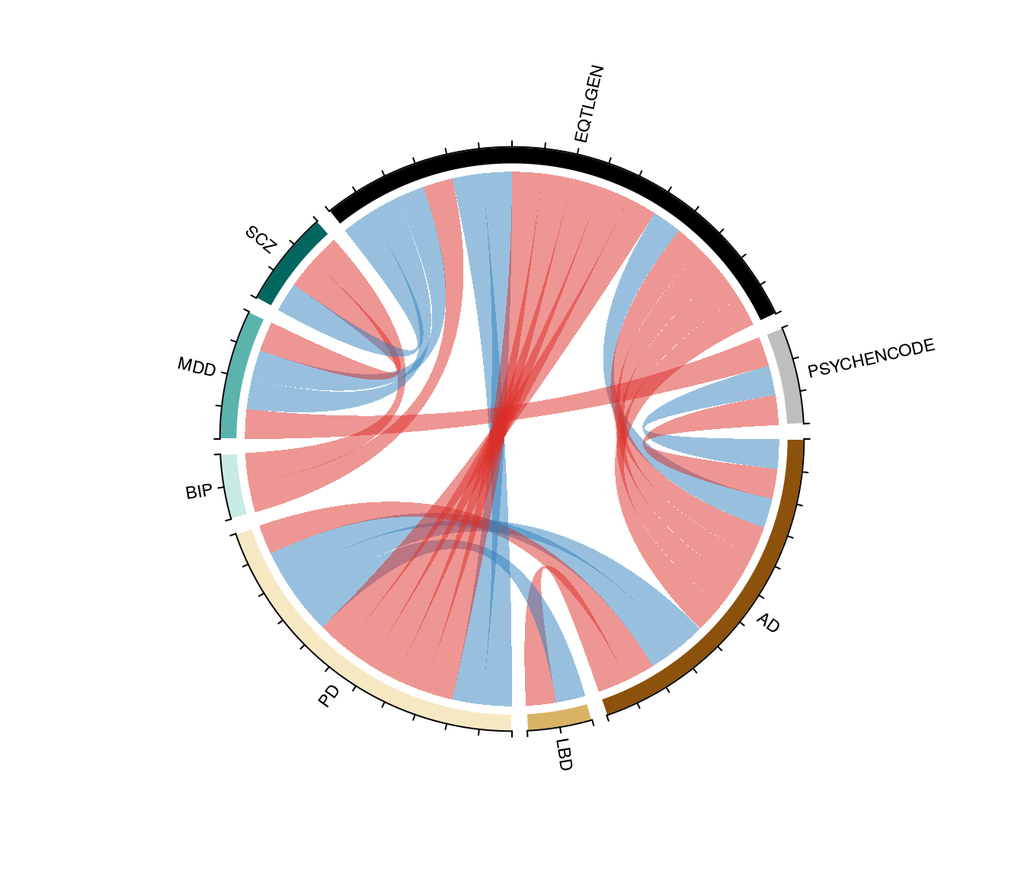

Figure 4.1: Chord diagram showing the number of **distinct** significant bivariate local genetic correlations between each of the traits across all LD blocks (Bonferroni-corrected p < 0.05). Pairs of disease phenotypes (which were tested across multiple genes within an LD block) were collapsed and their average rho within the LD block used. Positive and negative correlations are coloured red and blue, respectively.

```r
data_to_plot <-
  bivar_bonf %>%
  dplyr::filter(!str_detect(phen2, "ENSG")) %>%
  dplyr::distinct(ld_block, phen1, phen2, rho) %>%
  dplyr::group_by(ld_block, phen1, phen2) %>%
  dplyr::summarise(rho = mean(rho)) %>%
  dplyr::bind_rows(
    bivar_bonf %>%
      dplyr::filter(str_detect(phen2, "ENSG")) %>%
      dplyr::distinct(eqtl_dataset, ld_block, phen1, phen2, rho) %>%
      dplyr::mutate(
        phen2 =
          case_when(
            str_detect(phen2, "ENSG") ~ eqtl_dataset,
            TRUE ~ phen2
          )
      ) %>%
      dplyr::select(ld_block, phen1, phen2, rho)
  ) %>%
  dplyr::ungroup()

plot_bivar_chord_diagram(
  bivar_corr = data_to_plot,
  fct_phen = c(fct_disease, "EQTLGEN", "PSYCHENCODE"),
  palette = c(RColorBrewer::brewer.pal(n = 6, name = "BrBG"), "black", "grey")
)
```

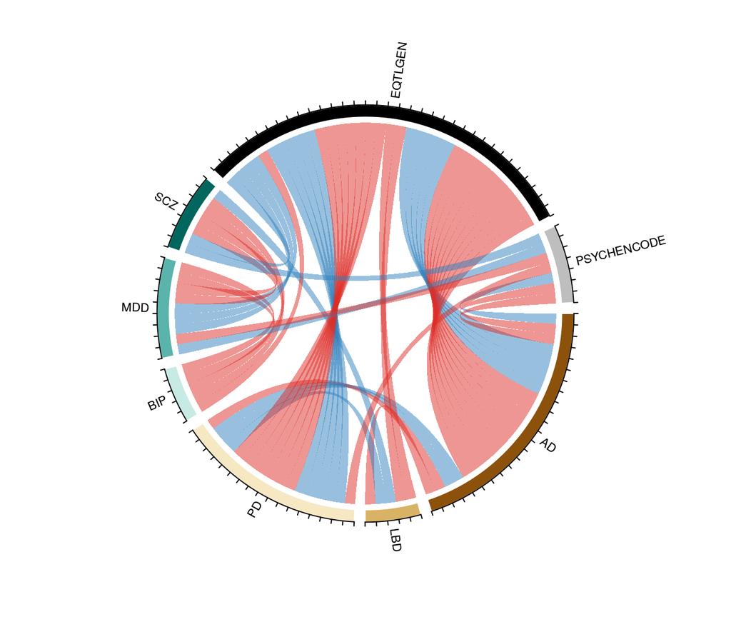

Figure 4.2: Chord diagram showing the number of **distinct** significant bivariate local genetic correlations between each of the traits across all LD blocks (FDR-corrected p < 0.05). Pairs of disease phenotypes (which were tested across multiple genes within an LD block) were collapsed and their average rho within the LD block used. Positive and negative correlations are coloured red and blue, respectively.

```r
data_to_plot <-
  bivar_fdr %>%
  dplyr::filter(!str_detect(phen2, "ENSG")) %>%
  dplyr::distinct(ld_block, phen1, phen2, rho) %>%
  dplyr::group_by(ld_block, phen1, phen2) %>%
  dplyr::summarise(rho = mean(rho)) %>%
  dplyr::bind_rows(
    bivar_fdr %>%
      dplyr::filter(str_detect(phen2, "ENSG")) %>%
      dplyr::distinct(eqtl_dataset, ld_block, phen1, phen2, rho) %>%
      dplyr::mutate(
        phen2 =
          case_when(
            str_detect(phen2, "ENSG") ~ eqtl_dataset,
            TRUE ~ phen2
          )
      ) %>%
      dplyr::select(ld_block, phen1, phen2, rho)
  ) %>%
  dplyr::ungroup()

plot_bivar_chord_diagram(
  bivar_corr = data_to_plot,
  fct_phen = c(fct_disease, "EQTLGEN", "PSYCHENCODE"),
  palette = c(RColorBrewer::brewer.pal(n = 6, name = "BrBG"), "black", "grey")
)
```

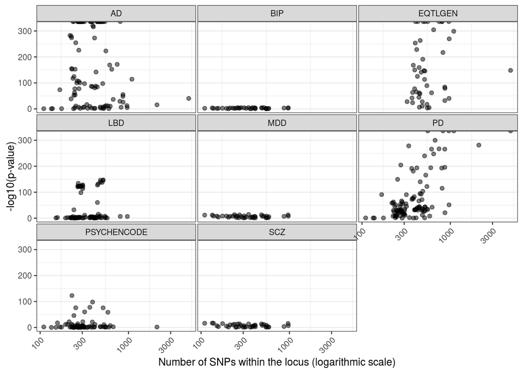

Figure 4.3: Scatter plot of number of SNPs in a tested gene locus and the p-value from the univariate test for each trait.

```r
results$univ %>%
  dplyr::mutate(
    phen =
      case_when(
        str_detect(phen, "ENSG") ~ eqtl_dataset,
        TRUE ~ phen
      )
  ) %>%
  ggplot(
    aes(
      x = n_snps,
      y = -log10(p)
    )
  ) +
  geom_point(alpha = 0.5) +
  scale_x_log10() +
  scale_colour_manual(
    values = c(RColorBrewer::brewer.pal(n = 6, name = "BrBG"), "black", "grey")
  ) +
  facet_wrap(vars(phen)) +
  labs(
    x = "Number of SNPs within the locus (logarithmic scale)",
    y = "-log10(p-value)"
  ) +
  theme_rhr
```